# MPDW Tugas Minggu 2

Dzulfikar Najib

2026-09-03

# Install & Load Packages

```r
# 1. Install paket remotes jika belum ada
# if (!require("remotes")) install.packages("remotes")

# 2. Install package orcutt langsung dari arsip CRAN
# remotes::install_version("orcutt", version = "2.3")
```

```r
# install.packages("lmtest")  # Untuk uji Durbin-Watson
# install.packages("HoRM")     # Untuk metode Hildreth-Lu
```

# Library

```r
library(lmtest)
library(orcutt)
library(HoRM)
```

# Input Data

```r
# Membaca file data IPM (sesuaikan nama/path file jika perlu)
data <- read.csv("ipm_panel_long_2010_2021.csv")
data
```

```
##                 Provinsi Tahun   IPM
## 1                   ACEH  2010 67.09
## 2                   ACEH  2011 67.45
## 3                   ACEH  2012 67.81
## 4                   ACEH  2013 68.30
## 5                   ACEH  2014 68.81
## 6                   ACEH  2015 69.45
## 7                   ACEH  2016 70.00
## 8                   ACEH  2017 70.60
## 9                   ACEH  2018 71.19
## 10                  ACEH  2019 71.90
## 11                  ACEH  2020 71.99
## 12                  ACEH  2021 72.18
## 13                  BALI  2010 70.10
## 14                  BALI  2011 70.87
```

[output cut: 394 more lines]

# Eksplorasi & Pemodelan OLS Awal:

Mengambil data Jawa tengah dan Membuat model regresi linier sederhana/berganda awal antara variabel terikat ($Y$) dan variabel bebas ($X$).

```r
data.jateng <- subset(data, Provinsi == "JAWA TENGAH")
str(data.jateng)
```

```
## 'data.frame':    12 obs. of  3 variables:
##  $ Provinsi: chr  "JAWA TENGAH" "JAWA TENGAH" "JAWA TENGAH" "JAWA TENGAH" ...
##  $ Tahun   : int  2010 2011 2012 2013 2014 2015 2016 2017 2018 2019 ...
##  $ IPM     : num  66.1 66.6 67.2 68 68.8 ...
```

```r
model <- lm(IPM ~ Tahun, data = data.jateng)
summary(model)
```

```
##
## Call:
## lm(formula = IPM ~ Tahun, data = data.jateng)
##
## Residuals:
##      Min       1Q   Median       3Q      Max
## -0.51436 -0.20550  0.09494  0.20190  0.31494
##
## Coefficients:
##               Estimate Std. Error t value Pr(>|t|)
## (Intercept) -1.106e+03  4.572e+01  -24.19 3.32e-10 ***
## Tahun        5.832e-01  2.269e-02   25.71 1.82e-10 ***
## ---
## Signif. codes:  0 '***' 0.001 '**' 0.01 '*' 0.05 '.' 0.1 ' ' 1
##
## Residual standard error: 0.2713 on 10 degrees of freedom
## Multiple R-squared:  0.9851, Adjusted R-squared:  0.9836
## F-statistic: 660.9 on 1 and 10 DF,  p-value: 1.822e-10
```

# Melakukan Uji Durbin-Watson

Melakukan pengecekan sisaan OLS awal menggunakan Uji Durbin-Watson (DW-Test) atau plot ACF/PACF residual.

1. Jika Nilai DW Lebih Kecil dari ($DW < d_U$). Arti: Terjadi autokorelasi positif.Penyebab: Pola error cenderung searah (jika error kemarin positif, hari ini kemungkinan besar positif).Efek: Standar error model menjadi terlalu kecil, membuat variabel independen terlihat signifikan padahal sebenarnya tidak.
2. Jika Nilai DW Lebih Besar dari ($DW > 4 - d_U$). Arti: Terjadi autokorelasi negatif.Penyebab: Pola error cenderung berlawanan arah secara ekstrem (jika error kemarin positif, hari ini negatif).Efek: Kasus ini lebih jarang terjadi, namun tetap merusak validitas uji signifikansi (uji t dan uji F).
3. Jika Nilai DW Berada di Antara ($d_L$) dan ($d_U$) Daerah Ragu-Ragu. Arti: Pengujian tidak menghasilkan kesimpulan pasti apakah ada autokorelasi atau tidak.

```r
dw_test <- dwtest(model)
dw_test
```

```
##
##  Durbin-Watson test
##
## data:  model
## DW = 0.53458, p-value = 6.938e-05
## alternative hypothesis: true autocorrelation is greater than 0
```

Dari hasil uji DW-Test, didapatkan nilai p-value $< 0.05$ atau statistik DW berada di luar rentang bebas autokorelasi ($d_U < DW < 4 - d_U$), yang mengindikasikan adanya autokorelasi.

# Penanganan Autokorelasi:

Meng estimasi parameter autokorelasi $\rho$ menggunakan dua pendekatan sekaligus:

## Metode Cochrane-Orcutt (iterasi hingga konvergen)

```r
modelCO <- cochrane.orcutt(model, convergence = 3)
modelCO
```

```
## Cochrane-orcutt estimation for first order autocorrelation
##
## Call:
## lm(formula = IPM ~ Tahun, data = data.jateng)
##
##  number of interaction: 31
##  rho 0.896676
##
## Durbin-Watson statistic
## (original):    0.53458 , p-value: 6.938e-05
## (transformed): 1.36633 , p-value: 5.977e-02
##
##  coefficients:
## (Intercept)       Tahun
## -421.992308    0.245256
```

```r
y <- data.jateng$IPM
x <- data.jateng$Tahun

rho <- modelCO$rho
y.transformed <- y[-1] - (y[-12] * rho)
x.transformed <- x[-1] - (x[-12] * rho)
model.t <- lm(y.transformed ~ x.transformed)
summary(model.t)
```

```
##
## Call:
## lm(formula = y.transformed ~ x.transformed)
##
## Residuals:
##      Min       1Q   Median       3Q      Max
## -0.25494 -0.13197  0.04027  0.13225  0.17738
##
## Coefficients:
##               Estimate Std. Error t value Pr(>|t|)
## (Intercept)   -43.6017    31.5557  -1.382    0.200
## x.transformed   0.2453     0.1508   1.626    0.138
##
## Residual standard error: 0.1635 on 9 degrees of freedom
## Multiple R-squared:  0.227,  Adjusted R-squared:  0.1412
## F-statistic: 2.644 on 1 and 9 DF,  p-value: 0.1384
```

```r
dwtest(model.t)
```

```
##
##  Durbin-Watson test
##
## data:  model.t
## DW = 1.3663, p-value = 0.05977
## alternative hypothesis: true autocorrelation is greater than 0
```

dari hasil uji DW-Test pada model Cochrane-Orcutt, didapatkan nilai p-value $> 0.05$ atau statistik DW berada di dalam rentang bebas autokorelasi ($d_U < DW < 4 - d_U$), yang mengindikasikan bahwa sisaan model sudah terbebas dari masalah autokorelasi.

## Metode Hildreth-Lu (pencarian $\rho$ optimal via minimasi SSE)

```r
hildreth.lu.func <- function(r, model){
  x <- model.matrix(model)[,-1]
  y <- model.response(model.frame(model))
  n <- length(y)
  t <- 2:n
  y <- y[t]-r*y[t-1]
  x <- x[t]-r*x[t-1]

  return(lm(y~x))
}

# Mencari rho yang meminimumkan SSE
r <- seq(0.1, 0.9, by = 0.1)
tab <- data.frame("rho" = r, "SSE" = sapply(r, function(i){deviance(hildreth.lu.func(i, model))}))
round(tab, 4)
```

```
##   rho    SSE
## 1 0.1 0.6116
## 2 0.2 0.5399
## 3 0.3 0.4754
## 4 0.4 0.4181
## 5 0.5 0.3680
## 6 0.6 0.3252
## 7 0.7 0.2895
## 8 0.8 0.2611
## 9 0.9 0.2399
```

```r
# Pencarian rho presisi tinggi
rOpt <- seq(0.9, 0.99, by = 0.001)
tabOpt <- data.frame("rho" = rOpt, "SSE" = sapply(rOpt, function(i){deviance(hildreth.lu.func(i, model))}))
head(tabOpt[order(tabOpt$SSE),])
```

```
##      rho       SSE
## 91 0.990 0.2269694
## 90 0.989 0.2270809
## 89 0.988 0.2271931
## 88 0.987 0.2273060
## 87 0.986 0.2274196
## 86 0.985 0.2275339
```

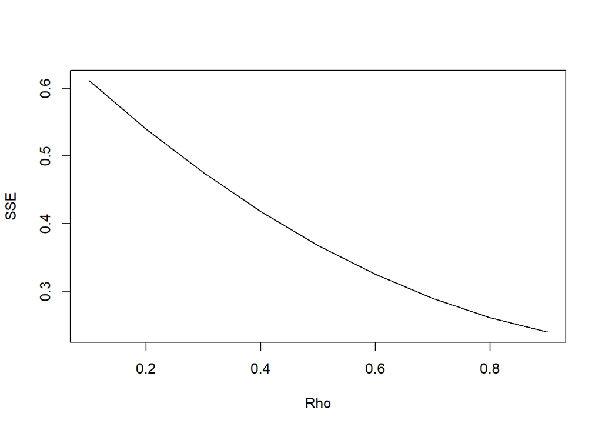

```r
par(mfrow = c(1,1))
plot(tab$SSE ~ tab$rho, type = "l", xlab = "Rho", ylab = "SSE")
abline(v = tabOpt[tabOpt$SSE == min(tabOpt$SSE), "rho"], lty = 2, col = "red", lwd = 2)
```

```r
# Mengambil rho optimal secara otomatis dari SSE terkecil
rho_opt <- tabOpt[which.min(tabOpt$SSE), "rho"]
modelHL <- hildreth.lu.func(rho_opt, model)
summary(modelHL)
```

```
##
## Call:
## lm(formula = y ~ x)
##
## Residuals:
##      Min       1Q   Median       3Q      Max
## -0.26082 -0.10654  0.02656  0.12776  0.17137
##
## Coefficients:
##             Estimate Std. Error t value Pr(>|t|)
## (Intercept)   68.302     32.024   2.133   0.0617 .
## x             -3.171      1.514  -2.094   0.0658 .
## ---
## Signif. codes:  0 '***' 0.001 '**' 0.01 '*' 0.05 '.' 0.1 ' ' 1
##
## Residual standard error: 0.1588 on 9 degrees of freedom
## Multiple R-squared:  0.3276, Adjusted R-squared:  0.2529
## F-statistic: 4.385 on 1 and 9 DF,  p-value: 0.06576
```

```r
dwtest(modelHL)
```

```
##
##  Durbin-Watson test
##
## data:  modelHL
## DW = 1.5498, p-value = 0.1144
## alternative hypothesis: true autocorrelation is greater than 0
```

Karena nilai p-value $> 0.05$ atau statistik DW berada di dalam rentang bebas autokorelasi ($d_U < DW < 4 - d_U$), maka sisaan model Hildreth-Lu sudah terbebas dari masalah autokorelasi.

# Langkah 4: Evaluasi dan Perbandingan Kebaikan Model

Membandingkan kebaikan model OLS Awal, Cochrane-Orcutt, dan Hildreth-Lu berdasarkan nilai *Sum of Squared Errors* (SSE), statistik Durbin-Watson (DW), serta *p-value*.

```r
# 1. Ekstraksi Metrik Model OLS Awal
sse_ols <- deviance(model)
dw_ols  <- dwtest(model)$statistic
p_ols   <- dwtest(model)$p.value

# 2. Ekstraksi Metrik Model Cochrane-Orcutt
sse_co  <- deviance(model.t)
dw_co   <- dwtest(model.t)$statistic
p_co    <- dwtest(model.t)$p.value

# 3. Ekstraksi Metrik Model Hildreth-Lu
sse_hl  <- deviance(modelHL)
dw_hl   <- dwtest(modelHL)$statistic
p_hl    <- dwtest(modelHL)$p.value

# 4. Menyusun Tabel Perbandingan
tabel_evaluasi <- data.frame(
  Metode = c("OLS Awal", "Cochrane-Orcutt", "Hildreth-Lu"),
  Rho = c("-", round(rho, 4), round(rho_opt, 4)),
  SSE = c(round(sse_ols, 5), round(sse_co, 5), round(sse_hl, 5)),
  DW_Statistik = c(round(dw_ols, 4), round(dw_co, 4), round(dw_hl, 4)),
  p_value = c(format.pval(p_ols, digits = 4),
              format.pval(p_co, digits = 4),
              format.pval(p_hl, digits = 4))
)

tabel_evaluasi
```

```
##            Metode    Rho     SSE DW_Statistik   p_value
## 1        OLS Awal      - 0.73599       0.5346 6.938e-05
## 2 Cochrane-Orcutt 0.8967 0.24048       1.3663   0.05977
## 3     Hildreth-Lu   0.99 0.22697       1.5498    0.1144
```

Berdasarkan tabel evaluasi di atas, kedua metode penanganan autokorelasi (Cochrane-Orcutt dan Hildreth-Lu) berhasil menaikkan nilai statistik Durbin-Watson mendekati angka 2 dan menghasilkan $p\text{-value} > 0.05$, yang menunjukkan sisaan model sudah terbebas dari masalah autokorelasi. Model terbaik dipilih berdasarkan nilai SSE terkecil dan statistik DW yang paling mendekati 2.

# Langkah 5: Ekstraksi Parameter & Formulasi Model Akhir

Mengembalikan nilai intersep hasil transformasi ($\hat{\beta}_0^*$) ke bentuk model asal ($\hat{\beta}_0 = \frac{\hat{\beta}_0^*}{1 - \rho}$) untuk menyusun persamaan regresi IPM Jawa Tengah.

## Mengambil parameter dari model terbaik (misal: Hildreth-Lu)

```r
b0_star <- coef(modelHL)[1]  # Intersep ter-transformasi
b1      <- coef(modelHL)[2]  # Koefisien variabel Tahun
```

## Mengembalikan nilai Intersep ke bentuk asal

```r
b0_asal <- b0_star / (1 - rho_opt)
```

## Menampilkan Ringkasan Parameter Akhir

```r
cat("================ PARAMETER MODEL AKHIR ================\n")
```

```
## ================ PARAMETER MODEL AKHIR ================
```

```r
cat("Nilai Intersep Asal (b0) :", round(b0_asal, 4), "\n")
```

```
## Nilai Intersep Asal (b0) : 6830.198
```

```r
cat("Nilai Koefisien Tahun (b1):", round(b1, 4), "\n")
```

```
## Nilai Koefisien Tahun (b1): -3.1705
```

```r
cat("Nilai Rho Terpilih        :", round(rho_opt, 4), "\n")
```

```
## Nilai Rho Terpilih        : 0.99
```

```r
cat("-------------------------------------------------------\n")
cat("Persamaan Penduga IPM Jawa Tengah:\n")
```

```
## Persamaan Penduga IPM Jawa Tengah:
```

```r
cat("IPM_hat =", round(b0_asal, 4), "+", round(b1, 4), "* Tahun\n")
```

```
## IPM_hat = 6830.198 + -3.1705 * Tahun
```